# GAM

2024-10-16

# Generalized Additive Models

We know that the formula for multiple linear regression is given by:

$$f(x) = b_0 + b_1 x_1 + b_2 x_2 + ... + b_p x_p$$

which harnesses many variables to make prediction for the response variable Y, however it assumes that the relationships between $x_i$ and y are linear.

We will introduce a model used when the relationship between predictor and response variable is nonlinear, which applies to nonlinear relationships like spline and polynomial, which is given by:

$$f(x) = b_0 + f_1(x_1) + f_2(x_2)+...+f_p(x_p)$$

## Backfitting

The **Backfitting Algorithm** is an iterative approach used primarily in the context of additive models. It provides a way to estimate the components of an additive model by sequentially adjusting each component until convergence.

The basic idea is to fit each component while keeping the others fixed, iteratively improving each one based on the residuals left by the other components. This process continues until all components reach a stable solution, meaning that additional iterations do not significantly change the estimates.

### Steps of the Backfitting Algorithm

Consider an additive model of the form:

$$y_i = f_1(x_{i1}) + f_2(x_{i2}) + \dots + f_p(x_{ip}) + \epsilon_i$$

where $y_i$ is the response variable, $f_j$ represents the component function associated with the $j$-th predictor $x_{ij}$, and $\epsilon_i$ is the error term. The backfitting algorithm estimates each $f_j$ iteratively as follows:

1. **Initialize** each component function, usually setting $f_j^{(0)}(x) = 0$ and $\hat{\alpha}=\frac{1}{N}\sum y_i$ for all $j = 1, 2, \dots, p$.
2. **Iterate** through each component $j$ in sequence:
   - Define the partial residuals for the $j$-th component as:

     $$f_j^{(k)} = \text{Smooth}\{[y_i - \hat{\alpha}- \sum_{l \neq j}
     f_l^{(k)}(x_{il})]_1^N\}$$
   - Update $f_j$ by weighted average:

     $$f_j^{(k+1)} = f_j^{(k)}-\frac{1}{N}\sum_{i=1}^Nf_j^{(k)}(x_{ij})$$

   where $\text{smooth}(\cdot)$ represents a smoothing function, such as a local regression or spline.
3. **Repeat** step 2 until convergence, where convergence is typically defined as the point when changes in all $f_j$ are below a predetermined tolerance.

## Import dataset

We will use the data for Boston Housing Price, we have the following variables in the dataset:

crim: per capita crime rate by town

zn: proportion of residential land zoned for lots over 25,000 sq.ft

indus: proportion of non-retail business acres per town

chas: Charles River dummy variable (= 1 if tract bounds river; 0 otherwise)

nox: nitric oxides concentration (parts per 10 million)

rm: average number of rooms per dwelling

age: proportion of owner-occupied units built prior to 1940

dis: weighted distances to five Boston employment centres

rad: index of accessibility to radial highways

tax: full-value property-tax rate per USD 10,000

ptratio: pupil-teacher ratio by town

black:$1000(B-0.63)^2$ where B is the proportion of blacks by town

lstat: percentage of lower status of the population

medv: median value of owner-occupied homes in USD 1000’s

```r
library(MASS)
data("BostonHousing", package = "mlbench")
```

Firstly, we will split the whole dataset into training set, validation set and test set:

```r
library(caret)
library(dplyr)
set.seed(000)
df <- BostonHousing %>% select(medv, nox, age, rm, lstat, crim, indus)
trainIndex <- createDataPartition(df$medv, p = 0.7,
                                  list = FALSE)
train <- df[trainIndex, ]
temp_data <- df[-trainIndex, ]
testIndex <- createDataPartition(temp_data$medv, p = 0.5,
                                       list = FALSE)
test <- temp_data[testIndex, ]
val <- temp_data[-testIndex, ]
```

In order to capture the relationship between each predictor and response variable, that is $f_i(x_i)$ we will plot the graph between those variables.

Observe that the data points for predictor variable age is non-normally distributed, we will try to normalize the variables in order to make it more suitable for statistical modeling.

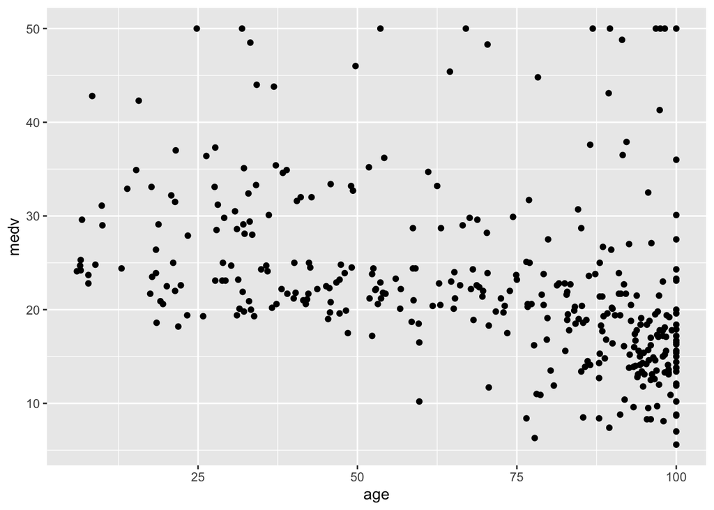

```r
library(ggplot2)
ggplot(train, aes(x = age, y = medv)) + geom_point()
```

```r
# VST Yeo-Johnson
library(car)
```

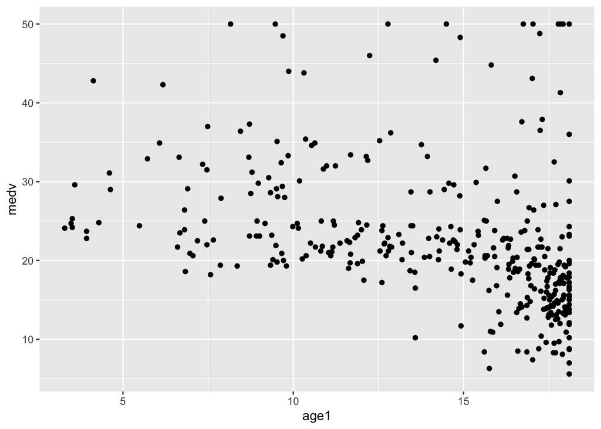

```r
#train$age1 <- bcnPower(train$age, lambda=0, gamma=2)
train$age1 <- yjPower(train$age, lambda = 0.5)
ggplot(train, aes(x = age1, y = medv)) + geom_point()
```

Plot medv against crim and decide which type of model could work well for this predictor. We will fit a spline function to the GAM.

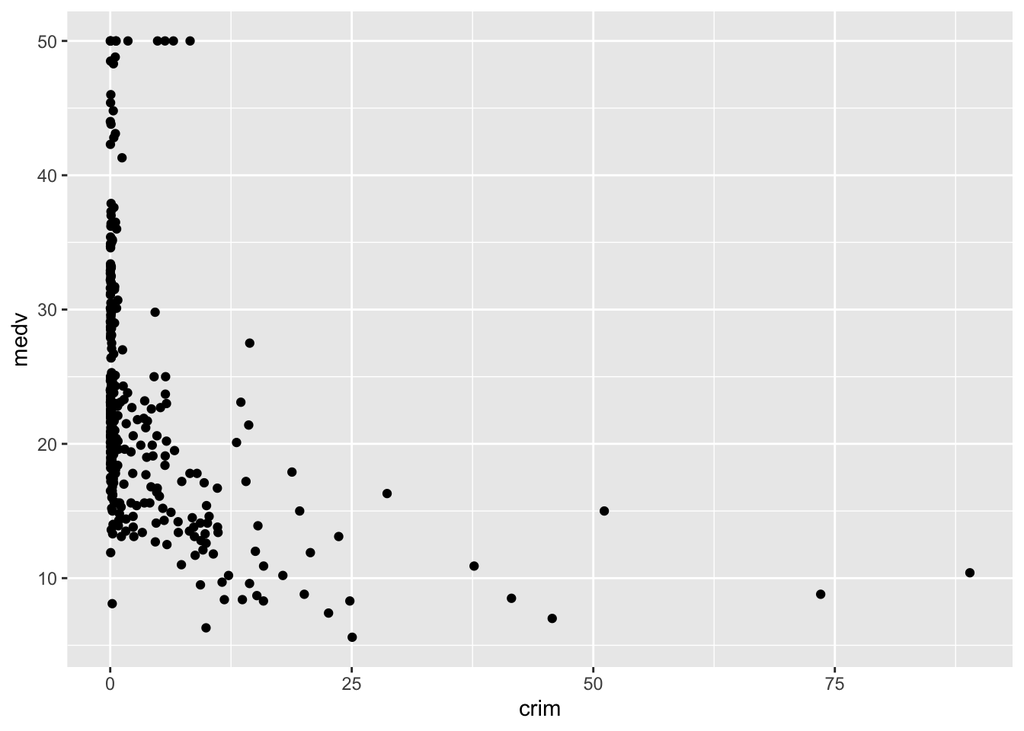

```r
library(ggplot2)
ggplot(train, aes(x = crim, y = medv)) + geom_point()
```

Plot medv against lstat and decide which type of model could work well for this predictor. We will fit a quadratic function to the GAM.

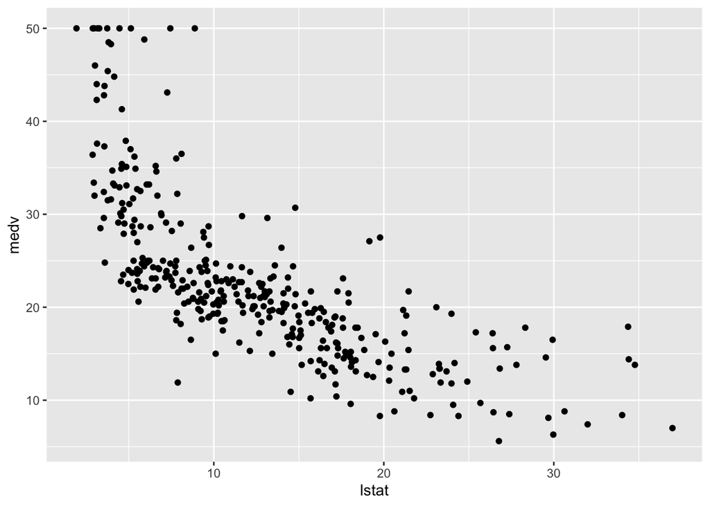

```r
ggplot(train, aes(x = lstat, y = medv)) + geom_point()
```

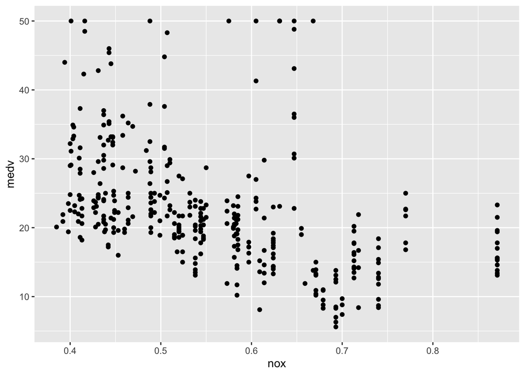

```r
ggplot(train, aes(x = nox, y = medv)) + geom_point()
```

Plot medv against rm and decide which type of model could work well for this predictor. We will fit a linear function to the GAM.

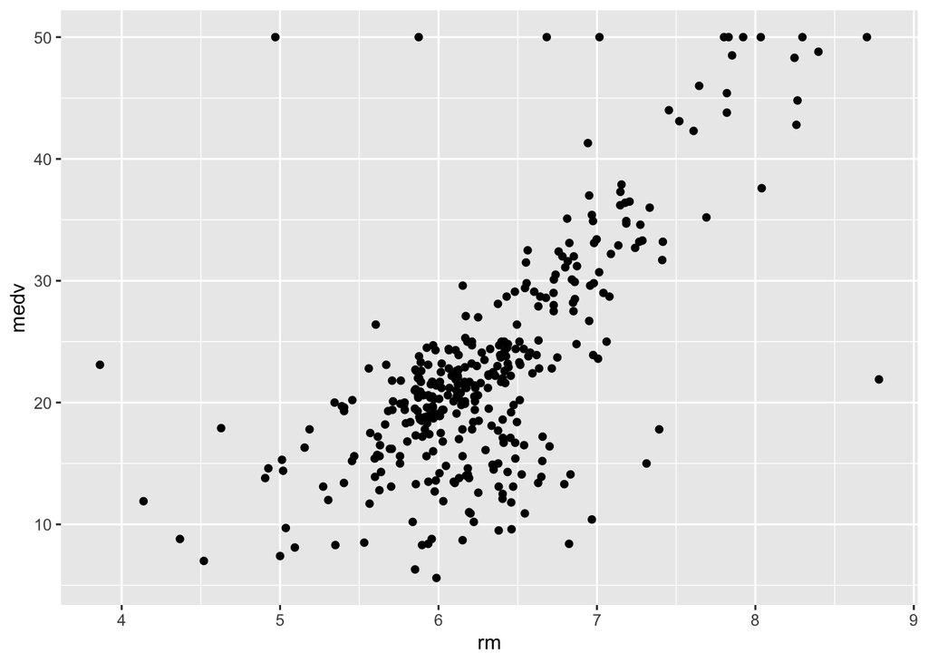

```r
ggplot(train, aes(x = rm, y = medv)) + geom_point()
```

Plot medv against indus and decide which type of model could work well for this predictor. We will fit a spline function to the GAM.

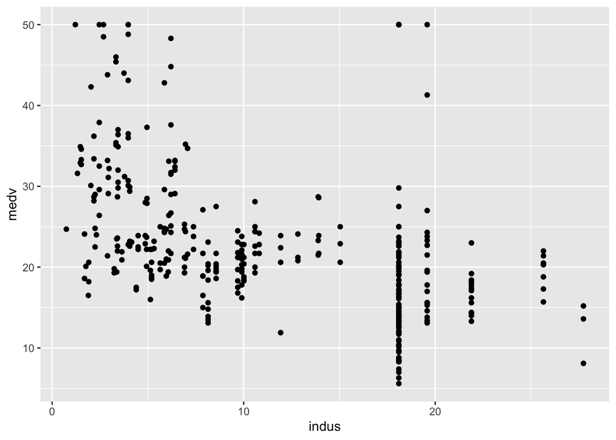

```r
ggplot(train, aes(x = indus, y = medv)) + geom_point()
```

## Fit the model

```r
library(gam)
library(mgcv)
#mdl <- gam(log(medv) ~ s(indus, bs='cr', k=5) + rm + poly(lstat, degree=2) + s(crim, bs='cr', k=5) + age + s(nox, k = 10, bs = "cr"), data = train)
mdl <- gam(medv ~ s(indus, bs='cr', k=5) + rm + poly(lstat, degree=2)
           + s(crim, bs='cr', k=5) + age,
           data = train)
```

```r
summary(mdl)
```

```
##
## Family: gaussian
## Link function: identity
##
## Formula:
## medv ~ s(indus, bs = "cr", k = 5) + rm + poly(lstat, degree = 2) +
##     s(crim, bs = "cr", k = 5) + age
##
## Parametric coefficients:
##                           Estimate Std. Error t value Pr(>|t|)
## (Intercept)               -3.11410    3.09507  -1.006  0.31505
## rm                         3.68522    0.50358   7.318  1.8e-12 ***
## poly(lstat, degree = 2)1 -99.65903    8.66390 -11.503  < 2e-16 ***
## poly(lstat, degree = 2)2  52.19742    5.30527   9.839  < 2e-16 ***
## age                        0.03683    0.01374   2.680  0.00771 **
## ---
## Signif. codes:  0 '***' 0.001 '**' 0.01 '*' 0.05 '.' 0.1 ' ' 1
##
## Approximate significance of smooth terms:
##            edf Ref.df     F  p-value
## s(indus) 3.781  3.958 3.004   0.0193 *
## s(crim)  3.939  3.996 9.089 1.22e-06 ***
## ---
## Signif. codes:  0 '***' 0.001 '**' 0.01 '*' 0.05 '.' 0.1 ' ' 1
##
## R-sq.(adj) =  0.727   Deviance explained = 73.6%
## GCV = 23.261  Scale est. = 22.43     n = 356
```

We can take a closer look at how the spline function performs on the data points for medv against Nox:

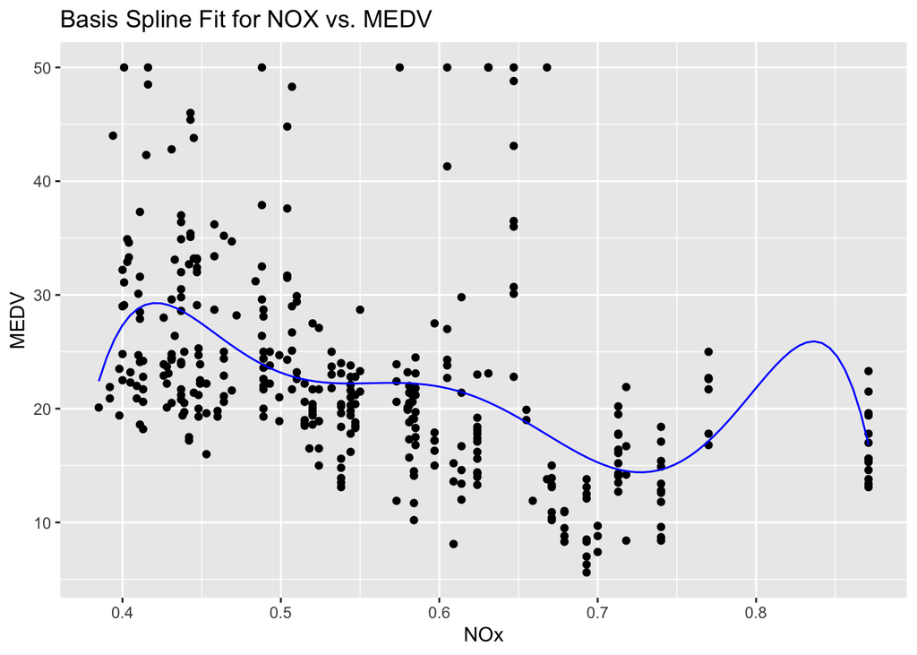

```r
fit <- lm(medv ~ bs(nox, degree = 6, knots = 5), data = train)

nox_grid <- data.frame(nox = seq(min(train$nox), max(train$nox), length.out = 100))
nox_grid$pred <- predict(fit, newdata = nox_grid)

ggplot(train, aes(x = nox, y = medv)) +
  geom_point() +
  geom_line(data = nox_grid, aes(x = nox, y = pred), color = "blue") +
  labs(title = "Basis Spline Fit for NOX vs. MEDV",
       x = "NOx",
       y = "MEDV")
```

Similarly, we can see how the linear function performs on the data for medv against rm.

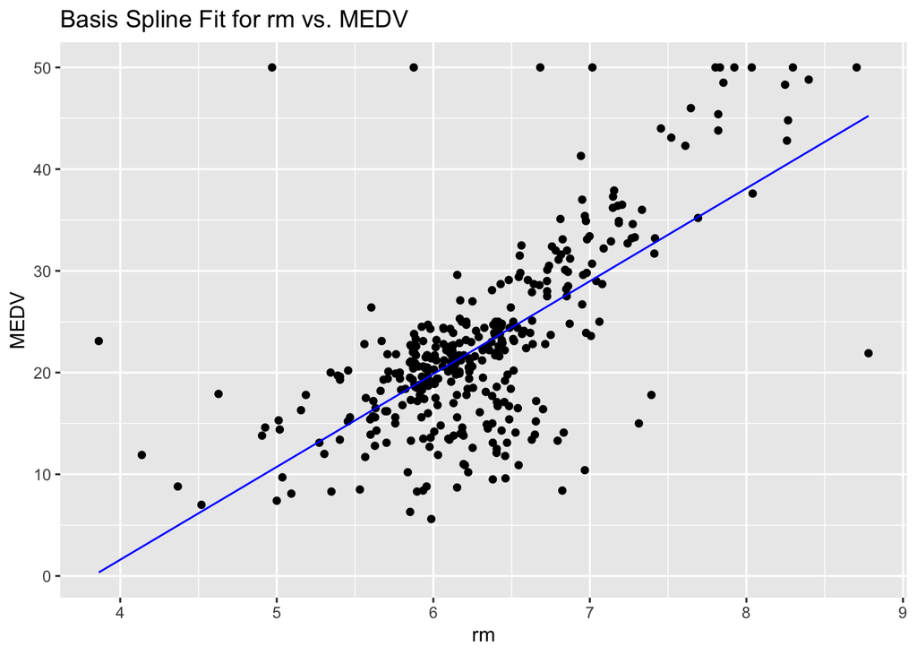

```r
fit <- lm(medv ~ rm, data = train)

rm_grid <- data.frame(rm = seq(min(train$rm), max(train$rm), length.out = 100))
rm_grid$pred <- predict(fit, newdata = rm_grid)

ggplot(train, aes(x = rm, y = medv)) +
  geom_point() +
  geom_line(data = rm_grid, aes(x = rm, y = pred), color = "blue") +
  labs(title = "Basis Spline Fit for rm vs. MEDV",
       x = "rm",
       y = "MEDV")
```

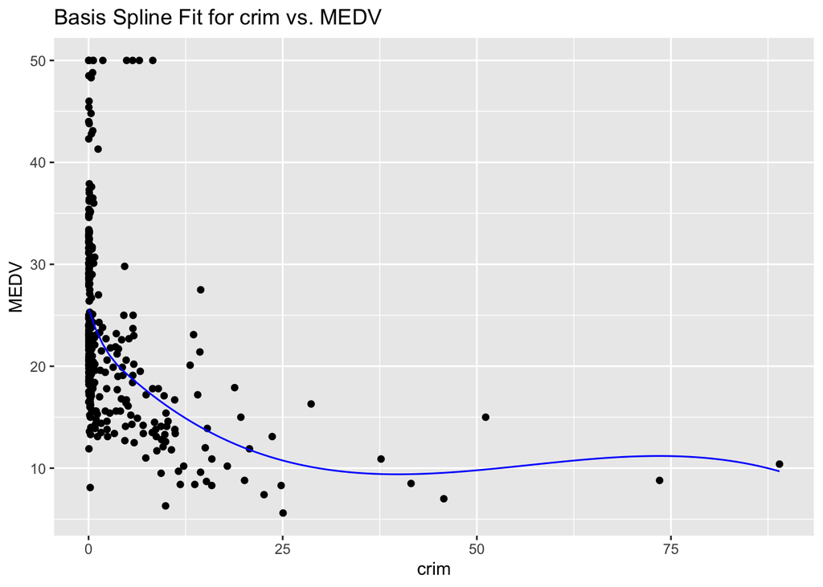

```r
fit <- lm(medv ~ bs(crim, degree = 3, knots = 5), data = train)

crim_grid <- data.frame(crim = seq(min(train$crim), max(train$crim), length.out = 100))
crim_grid$pred <- predict(fit, newdata = crim_grid)

ggplot(train, aes(x = crim, y = medv)) +
  geom_point() +
  geom_line(data = crim_grid, aes(x = crim, y = pred), color = "blue") +
  labs(title = "Basis Spline Fit for crim vs. MEDV",
       x = "crim",
       y = "MEDV")
```

Similarly, we can see how the linear function performs on the data for medv against age.

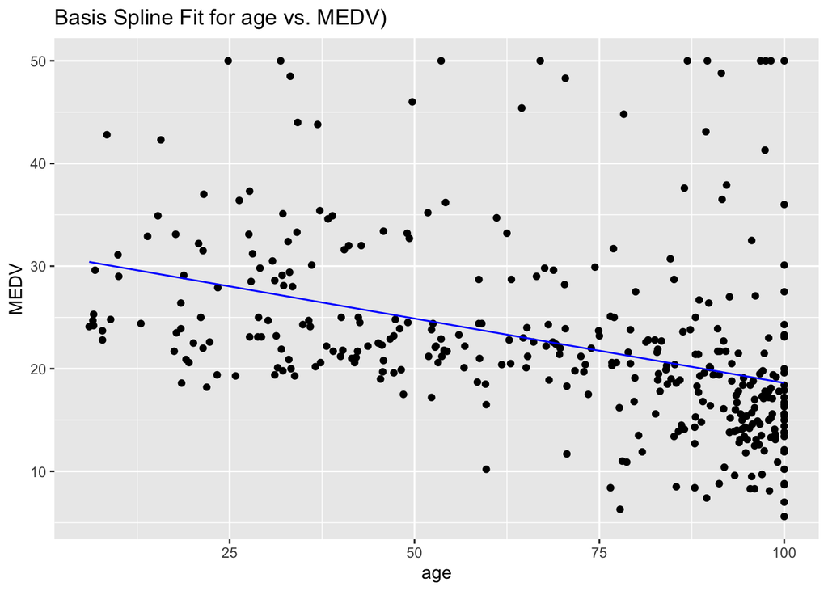

```r
fit <- lm(medv ~ age, data = train)

age_grid <- data.frame(age = seq(min(train$age), max(train$age), length.out = 100))
age_grid$pred <- predict(fit, newdata = age_grid)

ggplot(train, aes(x = age, y = medv)) +
  geom_point() +
  geom_line(data = age_grid, aes(x = age, y = pred), color = "blue") +
  labs(title = "Basis Spline Fit for age vs. MEDV)",
       x = "age",
       y = "MEDV")
```

# Making prediction using GAM

We will predict the medv in the validation set using the fitted GAM model and then calculate its mean squared error:

```r
val$pred <- predict(mdl, newdata = val)
mse <- mean((val$pred - val$medv)^2)
print(paste("Validation MSE:", mse))
```

```
## [1] "Validation MSE: 19.537888461558"
```

We will fit the data in a new linear model without any non linear relationships between predictor and response variables. And then calculate the mean squared error of the validation set for the new linear model:

```r
mdl2 <- lm(medv ~ nox + age + rm + lstat + crim + indus, data = train)
val$pred2 <- predict(mdl2, newdata = val)
mse2 <- mean((val$pred2 - val$medv)^2)
print(paste("Validation MSE on linear regression:", mse2))
```

```
## [1] "Validation MSE on linear regression: 30.7286702072614"
```

As we can see, the MSE for GAM is much smaller than that of the linear model, we conclude that GAM performs much better on datasets with non linear relationships.

Then we compute the MSE on the test data set to see if there is problem of overfitting.

```r
test$pred <- predict(mdl, newdata = test)
mse3 <- mean((test$pred - test$medv)^2)
print(paste("Test MSE:", mse3))
```

```
## [1] "Test MSE: 24.9108660925622"
```

```r
test$pred2 <- predict(mdl2, newdata = test)
mse4 <- mean((test$pred2 - test$medv)^2)
print(paste("Test MSE on linear regression:", mse4))
```

```
## [1] "Test MSE on linear regression: 31.0834062067661"
```

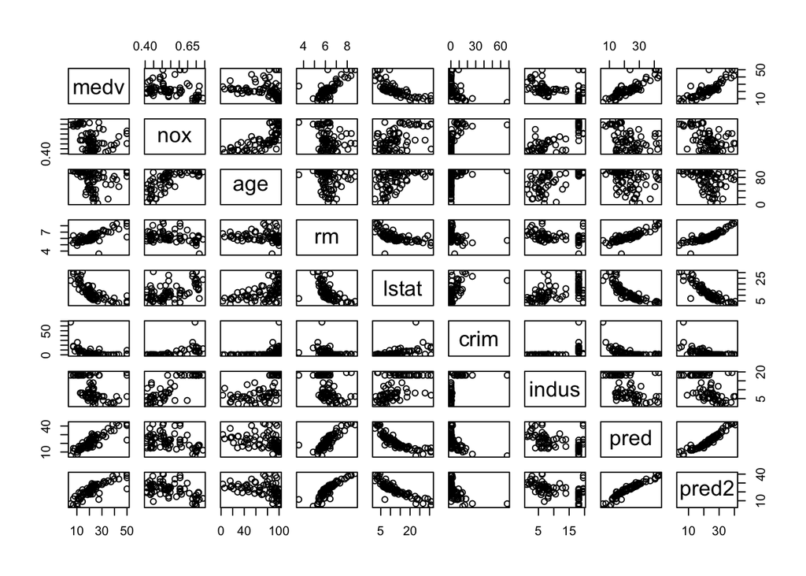

```r
pairs(test)
```